# Inferential - Statistics

#### The distribution is normal with a lot of outliers.

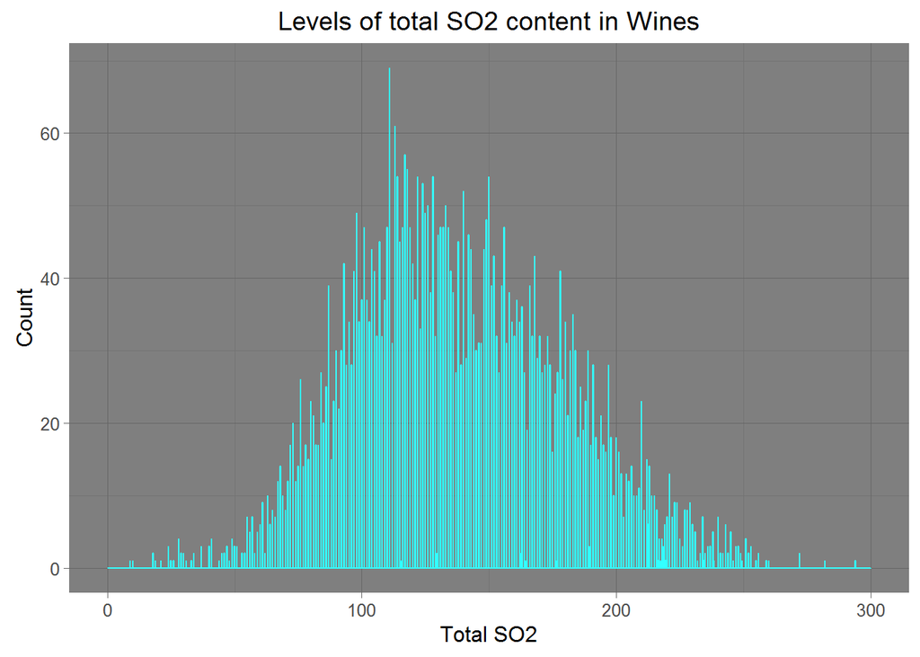

```r
# Total Sulphur Dioxide
ggplot(wh_wine, aes(total.sulfur.dioxide)) + geom_histogram(binwidth = 0.1, color = "#33FFFF",
    fill = "#CC99FF") + ggtitle("Levels of total SO2 content in Wines") + xlab("Total SO2") +
    ylab("Count") + xlim(0, 300) + theme_dark()
```

#### This distribution is also normal with couple of outliers.

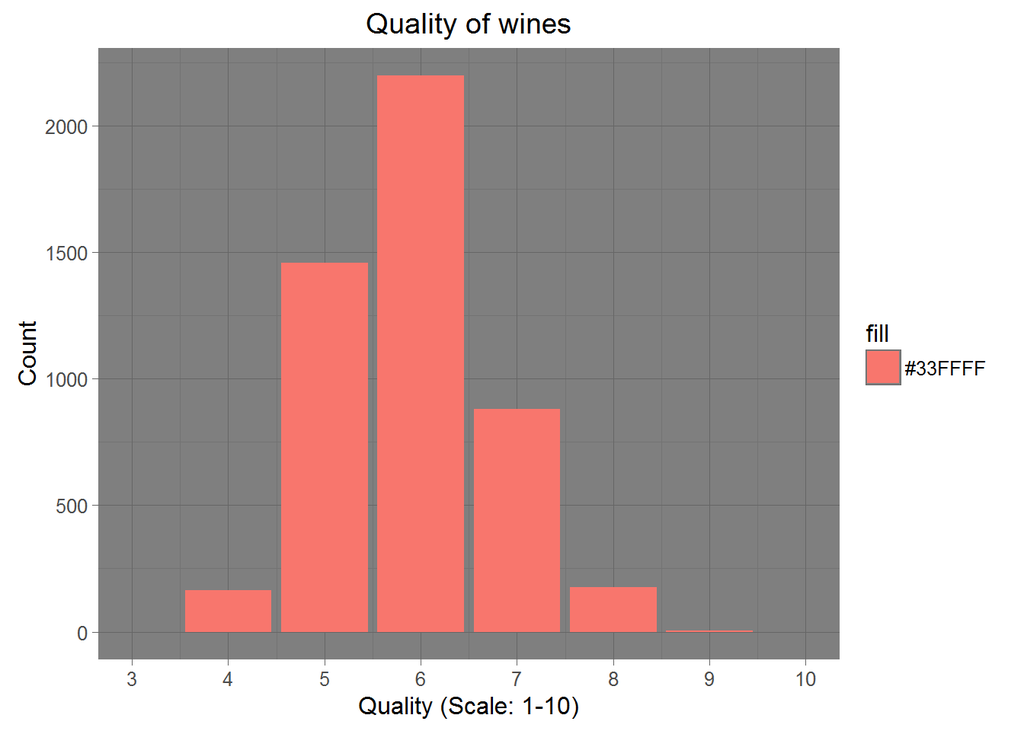

```r
## Quality:
ggplot(wh_wine, aes(quality, binwidth = 1, fill = "#33FFFF")) + geom_bar() + ggtitle("Quality of wines") +
    xlab("Quality (Scale: 1-10)") + ylab("Count") + scale_x_continuous(breaks = seq(3,
    10, 1), lim = c(3, 10)) + theme_dark()
```

#### There are lot of average wines and quite a few excellent and poor wines

## Doing a basic investigation to see correlations:

```r
cor(wh_wine)
```

```
##                      fixed.acidity volatile.acidity  citric.acid residual.sugar
## fixed.acidity           1.00000000      -0.02269729  0.289180698     0.08902070
## volatile.acidity       -0.02269729       1.00000000 -0.149471811     0.06428606
## citric.acid             0.28918070      -0.14947181  1.000000000     0.09421162
## residual.sugar          0.08902070       0.06428606  0.094211624     1.00000000
## chlorides               0.02308564       0.07051157  0.114364448     0.08868454
## free.sulfur.dioxide    -0.04939586      -0.09701194  0.094077221     0.29909835
## total.sulfur.dioxide    0.09106976       0.08926050  0.121130798     0.40143931
## density                 0.26533101       0.02711385  0.149502571     0.83896645
## pH                     -0.42585829      -0.03191537 -0.163748211    -0.19413345
## sulphates              -0.01714299      -0.03572815  0.062330940    -0.02666437
## alcohol                -0.12088112       0.06771794 -0.075728730    -0.45063122
## quality                -0.11366283      -0.19472297 -0.009209091    -0.09757683
## tot.acidity             0.98717874       0.07157062  0.394143356     0.10473749
##                        chlorides free.sulfur.dioxide total.sulfur.dioxide
## fixed.acidity         0.02308564       -0.0493958591          0.091069756
## volatile.acidity      0.07051157       -0.0970119393          0.089260504
## citric.acid           0.11436445        0.0940772210          0.121130798
## residual.sugar        0.08868454        0.2990983537          0.401439311
## chlorides             1.00000000        0.1013923521          0.198910300
## free.sulfur.dioxide   0.10139235        1.0000000000          0.615500965
## total.sulfur.dioxide  0.19891030        0.6155009650          1.000000000
## density               0.25721132        0.2942104109          0.529881324
## pH                   -0.09043946       -0.0006177961          0.002320972
## sulphates             0.01676288        0.0592172458          0.134562367
## alcohol              -0.36018871       -0.2501039415         -0.448892102
## quality              -0.20993441        0.0081580671         -0.174737218
## tot.acidity           0.04552987       -0.0451333172          0.113188502
##                          density            pH   sulphates     alcohol
## fixed.acidity         0.26533101 -0.4258582910 -0.01714299 -0.12088112
## volatile.acidity      0.02711385 -0.0319153683 -0.03572815  0.06771794
## citric.acid           0.14950257 -0.1637482114  0.06233094 -0.07572873
## residual.sugar        0.83896645 -0.1941334540 -0.02666437 -0.45063122
## chlorides             0.25721132 -0.0904394560  0.01676288 -0.36018871
## free.sulfur.dioxide   0.29421041 -0.0006177961  0.05921725 -0.25010394
## total.sulfur.dioxide  0.52988132  0.0023209718  0.13456237 -0.44889210
## density               1.00000000 -0.0935914935  0.07449315 -0.78013762
## pH                   -0.09359149  1.0000000000  0.15595150  0.12143210
## sulphates             0.07449315  0.1559514973  1.00000000 -0.01743277
## alcohol              -0.78013762  0.1214320987 -0.01743277  1.00000000
## quality              -0.30712331  0.0994272457  0.05367788  0.43557472
## tot.acidity           0.27560881 -0.4306513315 -0.01185225 -0.11751272
##                           quality tot.acidity
## fixed.acidity        -0.113662831  0.98717874
## volatile.acidity     -0.194722969  0.07157062
## citric.acid          -0.009209091  0.39414336
## residual.sugar       -0.097576829  0.10473749
## chlorides            -0.209934411  0.04552987
## free.sulfur.dioxide   0.008158067 -0.04513332
## total.sulfur.dioxide -0.174737218  0.11318850
## density              -0.307123313  0.27560881
## pH                    0.099427246 -0.43065133
## sulphates             0.053677877 -0.01185225
## alcohol               0.435574715 -0.11751272
## quality               1.000000000 -0.13137721
## tot.acidity          -0.131377207  1.00000000
```

## Initial Correlation Analysis:

1. Quality which is the outcome variable has only stronger positive correlation with alcohol and negative correlation with density.
2. As hypothesised, free sulphur and total sulphur dioxide have strong positive correlation with each other.
3. pH has negative correlation with fixed acidity and also with total acidity if considered.
4. Residual sugar has positive correlation with total sulphur dioxide while strong positive correlation with density. While it has negative correlation with alcohol.
5. Density have strong negative correlation with alcohol and positive correlation with total sulphur dioxide.

## Bivariate Plots- if variables are related

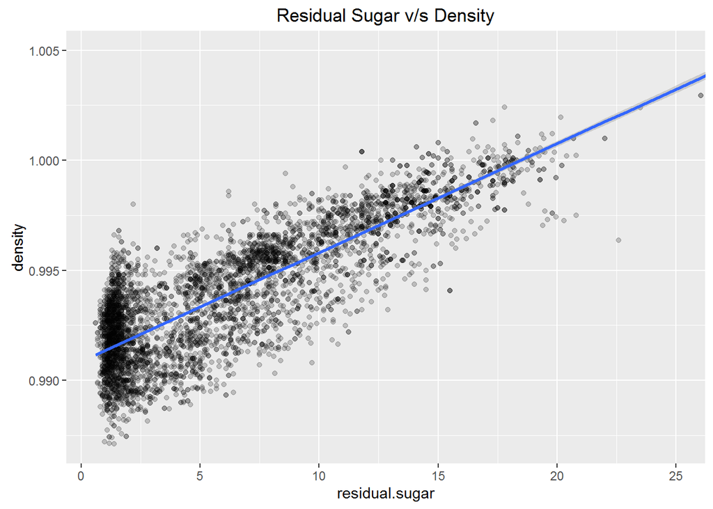

```r
## Residual sugar v/s Density :
ggplot(wh_wine, aes(residual.sugar, density)) + geom_point(alpha = 0.2) + geom_smooth(method = "lm") +
    ggtitle("Residual Sugar v/s Density") + coord_cartesian(xlim = c(min(wh_wine$residual.sugar),
    25), ylim = c(min(wh_wine$density), 1.005))
```

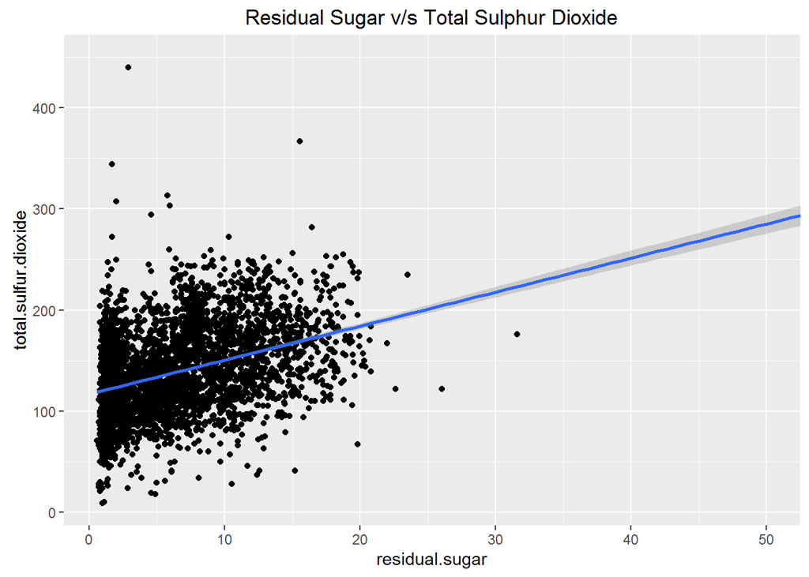

```r
# Residual Sugar v/s Total Sulphur Dioxide:
ggplot(wh_wine, aes(residual.sugar, total.sulfur.dioxide)) + geom_point() + geom_smooth(method = lm) +
    ggtitle("Residual Sugar v/s Total Sulphur Dioxide") + coord_cartesian(xlim = c(min(wh_wine$residual.sugar),
    50), ylim = c(min(wh_wine$total.sulfur.dioxide), 450))
```

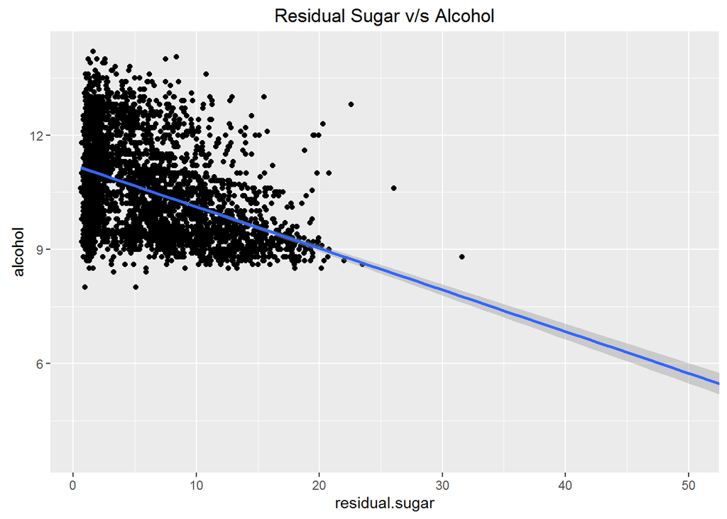

```r
# Residual Sugar v/s Alcohol:
ggplot(wh_wine, aes(residual.sugar, alcohol)) + geom_point() + geom_smooth(method = lm) +
    ggtitle("Residual Sugar v/s Alcohol") + coord_cartesian(xlim = c(min(wh_wine$residual.sugar),
    50))
```

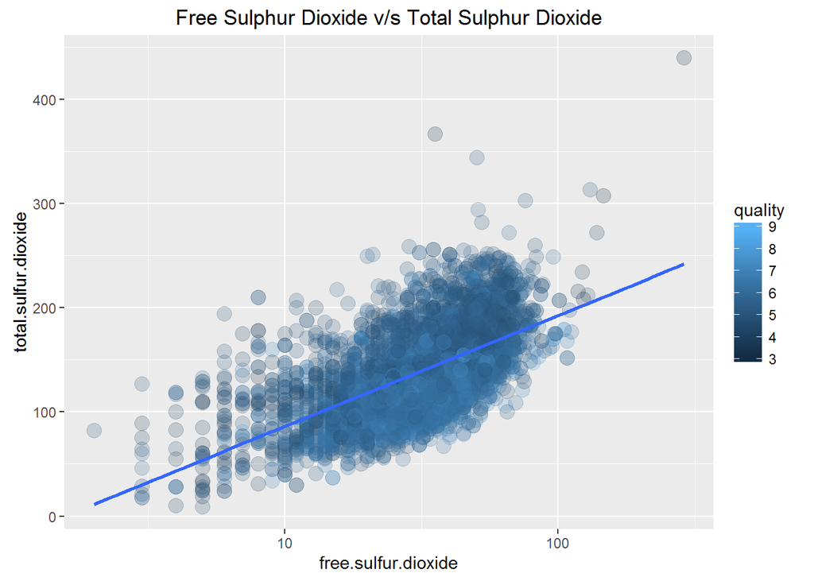

```r
# Free sulphur dioxide v/s Total sulphur dioxide:
ggplot(wh_wine, aes(free.sulfur.dioxide, total.sulfur.dioxide, color = quality)) +
    geom_point(size = 4, alpha = 0.2) + geom_smooth(method = lm, se = FALSE) + ggtitle("Free Sulphur Dioxide v/s Total Sulphur Dioxide") +
    scale_x_log10()
```

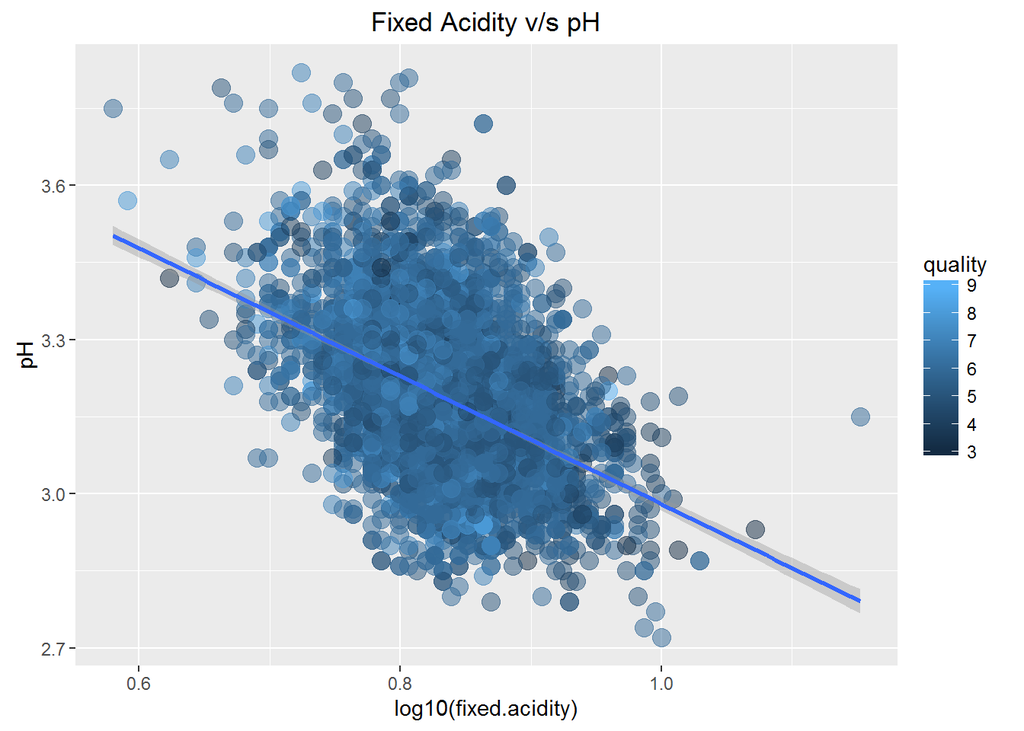

```r
# Fixed Acidity v/s pH:
ggplot(wh_wine, aes(log10(fixed.acidity), pH, color = quality)) + geom_point(size = 4,
    alpha = 0.5) + geom_smooth(method = "lm") + ggtitle("Fixed Acidity v/s pH")
```

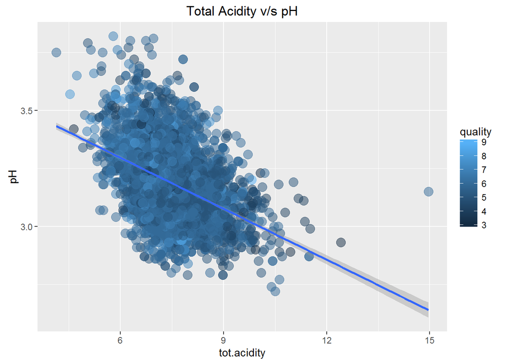

```r
# Total Acidity v/s pH:
ggplot(wh_wine, aes(tot.acidity, pH, color = quality)) + geom_point(size = 4, alpha = 0.5) +
    geom_smooth(method = "lm") + ggtitle("Total Acidity v/s pH")
```

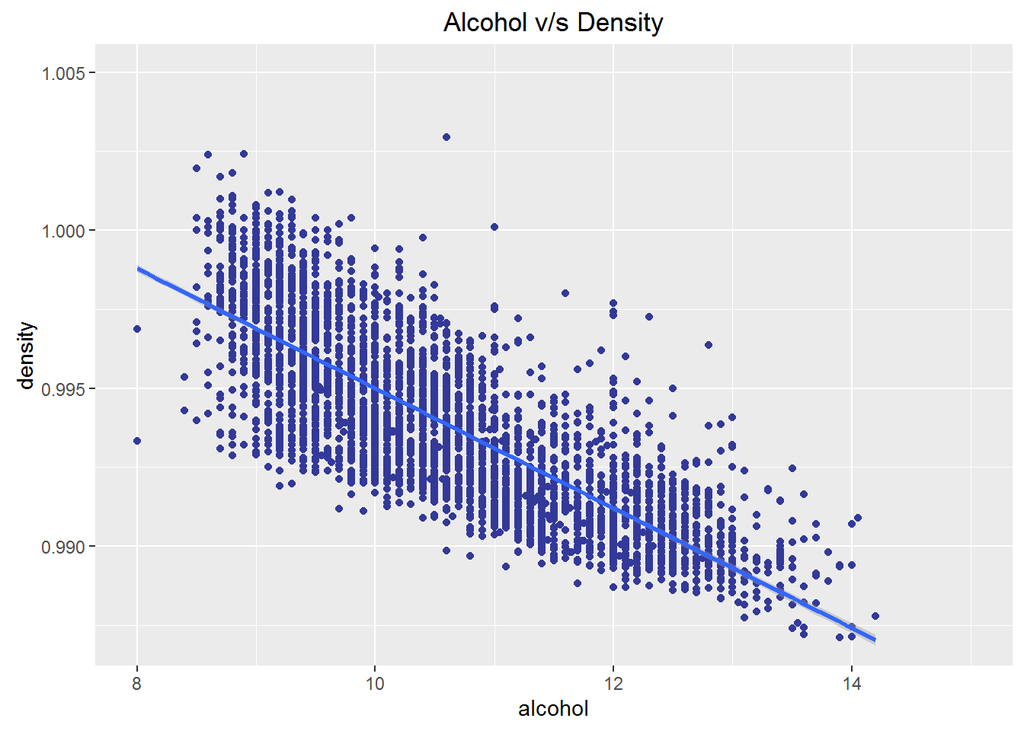

```r
# Alcohol v/s Density:
ggplot(wh_wine, aes(alcohol, density)) + geom_point(color = "#333999") + geom_smooth(method = lm) +
    ggtitle("Alcohol v/s Density") + coord_cartesian(ylim = c(min(wh_wine$density),
    1.005), xlim = c(min(wh_wine$alcohol), 15))
```

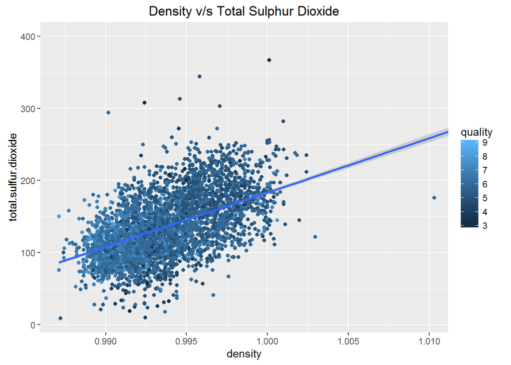

```r
# Density v/s Total Sulphur Dioxide:
ggplot(wh_wine, aes(density, total.sulfur.dioxide, color = quality)) + geom_point() +
    geom_smooth(method = lm) + ggtitle("Density v/s Total Sulphur Dioxide") + coord_cartesian(xlim = c(min(wh_wine$density),
    1.01), ylim = c(min(wh_wine$total.sulfur.dioxide), 400))
```

## Multivariate Plots:

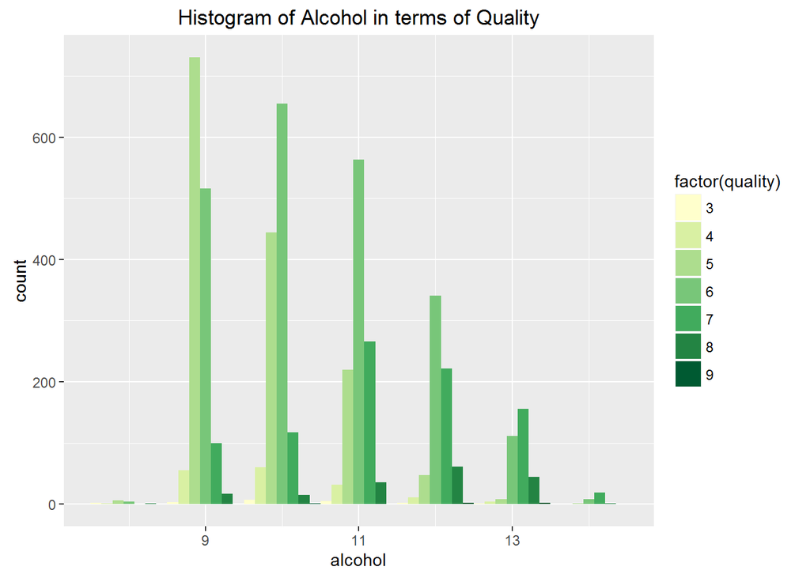

```r
# Alcohol v/s Quality:
ggplot(wh_wine, aes(alcohol)) + geom_histogram(aes(fill = factor(quality)), binwidth = 1,
    position = "dodge") + scale_fill_brewer(type = "seq", palette = 15) + ggtitle("Histogram of Alcohol in terms of Quality")
```

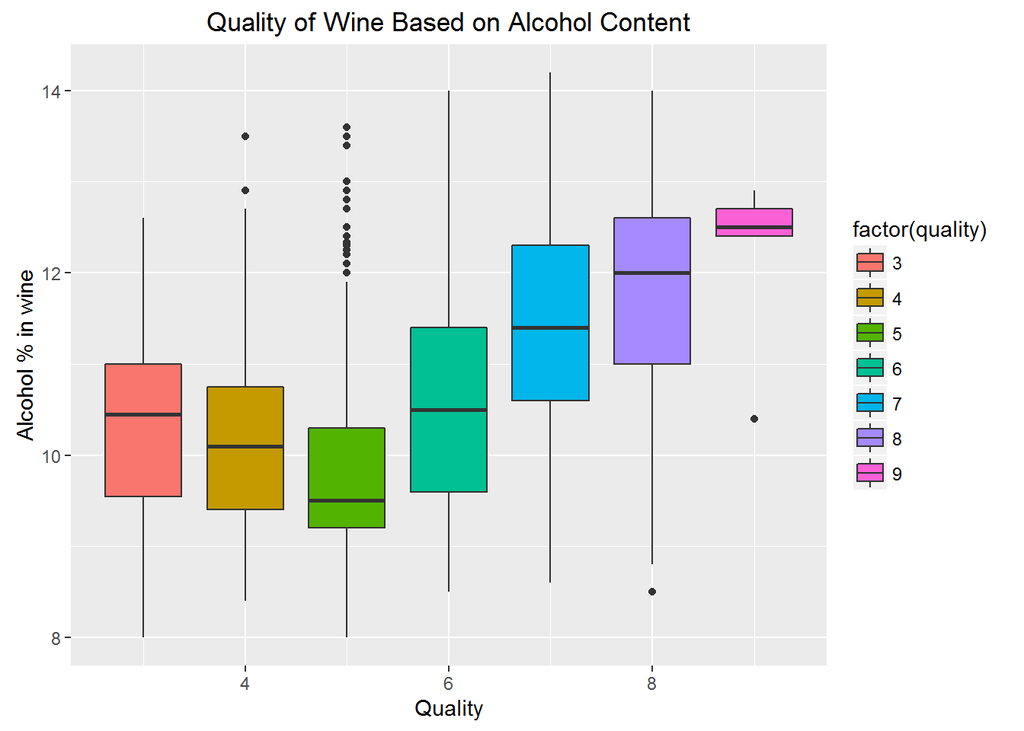

```r
# Alcohol v/s Quality:
ggplot(wh_wine, aes(quality, alcohol, fill = factor(quality))) + geom_boxplot() +
    ggtitle("Quality of Wine Based on Alcohol Content") + xlab("Quality") + ylab("Alcohol % in wine")
```

```r
## Both the above plots show how alcohol content affects the quality. The box plot
## shows how higher content of alcohol can give higher quality of wine. However
## there are some outliers, other variables which might be affect the quality of
## wines. Alcohol content alone would not produce higher quality.
```

### Reflection:

#### From the analysis I have done here, it is very clear that the quality of wines could not only be estimated on one’s individual taste but other factors like viticulture (way grapes are grown) and how they are turned into wine, type of grapes used, region and many more. It is more of subjective measure.